A conversation on latinidad

# ¿Existe el voto latine?

Is there a Latine vote?

**Latine** (la-TEE-neh): gender-inclusive, and easy to say in Spanish and English.

Who we are, how we voted in 2024, and what may happen on November 3.

**Ago Echeverri**Political Science, Stony Brook UniversityFall 2026

1 · ¿De dónde venimos? Where do we come from?

## Sixty-eight million people, many stories

68MLatine people in the U.S. in 2024, one in five Americans

57%of Latine people are of Mexican origin, about 40 million people

9.3MPuerto Ricans: 6.1M in the 50 states and D.C., 3.2M on the island

8more origin groups of 1M+: Cuban, Salvadoran, Dominican, Guatemalan, Colombian, Honduran, Venezuelan, Ecuadorian

×2Venezuelans, the fastest-growing group, doubled from 2019 to 2024

68%speak Spanish at home, down from 78% in 2000

Pew Research Center, “Key facts about U.S. Latinos,” Oct. 22, 2025 (2024 ACS data).

1 · Tres mitos Three myths

## Three things everyone “knows” about the Latine vote

True or false? Raise your hand before each one flips.

Myth 1

Latine voters are one bloc, and that bloc belongs to the Democrats.

**What Abrajano and Alvarez found**

Not a monolith. Party loyalties are still up for grabs: many identify as independents, and Bush won at least 40% in 2004.

Today: Trump won 48% in 2024.

Myth 2

Latine voters care mostly about “Latine issues” like immigration and bilingual education.

**What Abrajano and Alvarez found**

So much diversity means no single agenda. Puerto Ricans, who are citizens, see immigration differently from Cubans and Mexicans. In 2008 the economy pushed immigration aside.

Today: the economy and other cross-cutting issues, like cost of living, health care and housing, matter greatly to Latine voters.

Myth 3

Latine voters are a “sleeping giant” who just don’t participate.

**What Abrajano and Alvarez found**

Participation follows resources and contact. People vote when someone asks them, and parties often have not asked, or not in a way that fits the community.

Today: 45% of Latine men said no one contacted them in 2024.

Marisa A. Abrajano and R. Michael Alvarez, *New Faces, New Voices: The Hispanic Electorate in America* (Princeton University Press, 2010), Introduction. 2024: Pew validated voters; ANES 2024; Brookings (Sanchez, Nov. 2024).

1 · ¿Quién votó por quién? Who voted for whom?

2 · Una identidad construida A constructed identity

## “Hispanic” was invented, and that is part of the story

U.S. Census 1980 · Question 7

#### Is this person of Spanish/Hispanic origin or descent?

- No (not Spanish/Hispanic)
- Yes, Mexican, Mexican-Amer., Chicano
- Yes, Puerto Rican
- Yes, Cuban
- Yes, other Spanish/Hispanic

1960Mexicans, Puerto Ricans and Cubans are counted as white. There is no national Latine public.

1970An origin question appears, but only on a sample of census forms.

1980The Hispanic question goes on every form. Activists, bureaucrats and Spanish-language TV (SIN, later Univision) build one national category and one audience.

G. Cristina Mora, *Making Hispanics* (University of Chicago Press, 2014). Form text recreated for this talk.

2 · Desde abajo From below

## It was also built from below, in coalition

Sep 81965 · Filipino grape workers (AWOC, Larry Itliong) walk out in Delano, California.

Sep 16Mexican-American workers (NFWA, César Chávez and Dolores Huerta) vote to join, on Mexican Independence Day.

1966The two unions merge into what becomes the United Farm Workers.

1970Growers sign contracts after a five-year strike and a national boycott.

¡HUELGA!Strike!Delano · 1965

Delano grape strike, 1965–1970 (Welga Digital Archive; Farmworker Movement Documentation Project).

2 · La Patria Grande The Great Homeland

## Before any label, Latin American kids learn that our peoples are one

Simón Bolívar · Carta de Jamaica, 1815

> “Es una idea grandiosa pretender formar de todo el Mundo Nuevo una sola nación con un solo vínculo que ligue sus partes entre sí y con el todo.”

It is a grand idea to try to make the whole New World a single nation, with a single bond tying its parts to each other and to the whole.

> “Mas no es posible, porque climas remotos, situaciones diversas, intereses opuestos, caracteres desemejantes, dividen a la América.”

But it is not possible, because distant climates, different situations, opposing interests and unlike characters divide America.

José Martí · Nuestra América, 1891

> “Los pueblos que no se conocen han de darse prisa para conocerse, como quienes van a pelear juntos.”

Peoples who do not know each other must hurry to get to know each other, like those who are about to fight side by side.

> “Es la hora del recuento, y de la marcha unida, y hemos de andar en cuadro apretado, como la plata en las raíces de los Andes.”

It is the hour of reckoning and of marching together, and we must move in close ranks, like the silver in the roots of the Andes.

Bolívar, “Carta de Jamaica” (Kingston, Sept. 6, 1815); Martí, “Nuestra América,” *La Revista Ilustrada de Nueva York*, Jan. 1891. Translations for this talk.

2 · Lo que nos une What brings us together

## A shared “we” was also built on songs and stories

Music and telenovelas crossed borders that politics did not. People who had never met learned the same lyrics and cried over the same plots.

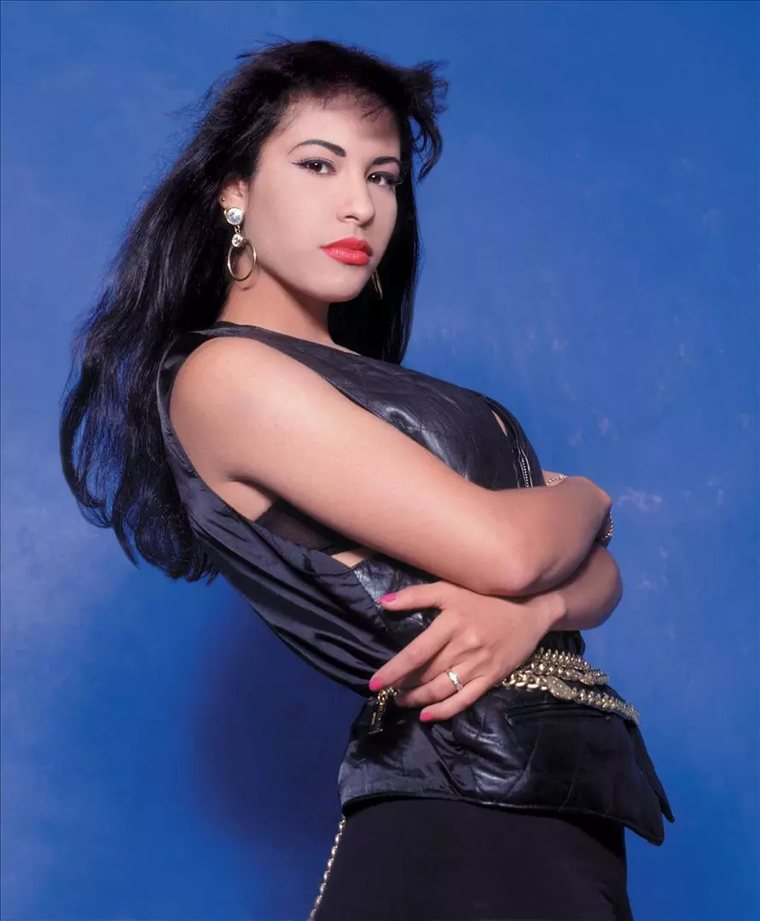

**Selena**Selena Quintanilla (1971–1995), a Mexican-American from Texas who sang Tejano and cumbia in Spanish. Grammy in 1994. In 1997 Jennifer Lopez, a Puerto Rican from the Bronx, played her on screen.

[figure not shown]

**Simplemente María**A Peruvian telenovela (1969) remade in Mexico (1989, Victoria Ruffo). A migrant woman from the countryside sews her way up in the city. Watched across the continent.

2 · La pregunta The question

If latinidad was built, why would we expect it to vote as one?

### What holds it together

Shared discrimination, linked fate, language, family, Spanish-language media.

### What pulls it apart

National origin, generation, religion, region, class, and, more and more, gender.

3 · El enigma The puzzle

## Threat should push Latine voters away. In 2024 it did not.

**The prediction.** When politicians attack the group, people who identify strongly with it mobilize against them. Pérez (2015) found this “ricochet” among Latine non-voters in an experiment.

**The puzzle.** Trump made immigration the center of three campaigns, and his share of the Latine vote went up each time.

Pérez, “Ricochet,” *Political Behavior* (2015). 2016: National Election Pool; 2020 and 2024: Pew Research Center validated voters (June 2025).

3 · Dónde pasó Where it happened

## The more Latine the county, the bigger the swing to Trump

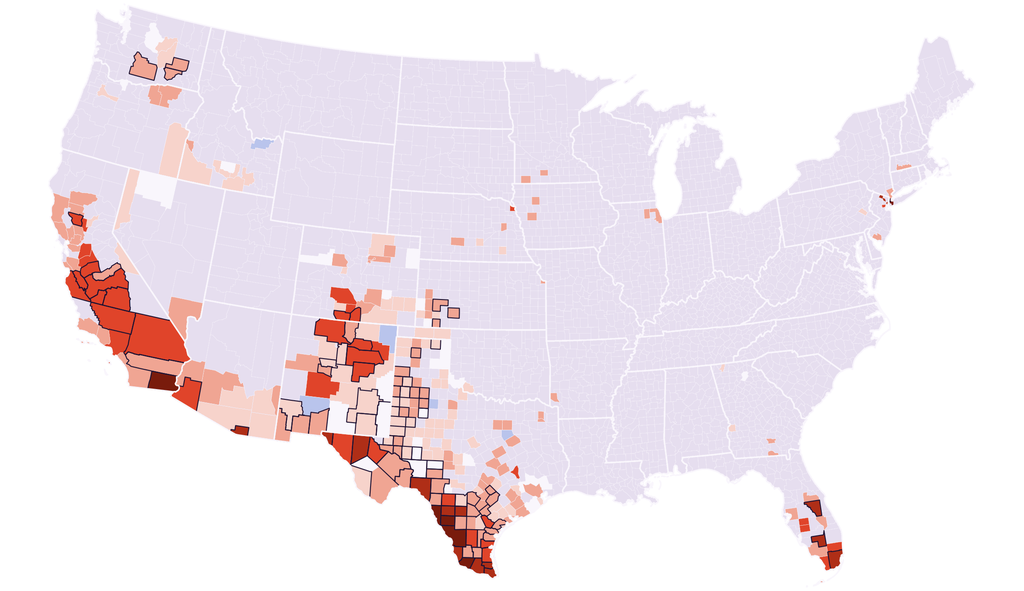

**Imperial, CA +25**flipped to Trump **Webb (Laredo), TX +25**flipped to Trump **Miami-Dade +19**flipped to Trump **The Bronx +22**still blue

D 5+D 2–5±2R 2–5R 5–10R 10–15R 15–20R 20+Latine majorityUnder 25% Latine

### Swing toward Trump, 2020 → 2024

Change in Republican margin, points, by % Latine in the county

<10%+2.8

10–25%+4.7

25–50%+8.0

50–75%+12.0

75%++20.0

96% of counties that are 25%+ Latine moved toward Trump.

**Careful:** these are counties, not people. A county can swing because of its non-Latine voters too.

County results 2020 and 2024 (tonmcg, US_County_Level_Election_Results); % Latine from Census ACS. Weighted by 2024 votes. Speaker’s analysis.

3 · Lo que dicen los votantes What voters say

3 · La misma palabra, otro sentido Same word, different meaning

## “Immigration” means different things, and so does trust

4 · Hombres y mujeres Men and women

## Every source agrees: Latine men are moving toward Trump faster

Among Latine men, exit polls show Clinton +31 in 2016, Biden +23 in 2020, and Trump +10 in 2024.

Pew validated voters (June 2025); American Electorate Voter Poll via Brookings (Nov. 2024); ANES 2024, speaker’s weighted estimate; National Exit Poll 2024; Edison exit polls 2016–2024 via Axios (Oct. 5, 2026).

4 · Jóvenes y mayores Young and old

## Age divides Latine voters less clearly than gender

### American Electorate Voter Poll

Latine men, share voting Trump, 2024

Under 4048%

40–5940%

60+37%

Younger men lean more toward Trump.

### ANES 2024

Latine men, share voting Trump, 2024

18–3934%

40–5939%

60+43%

Younger men lean less toward Trump.

American Electorate Voter Poll (BSP Research) via Brookings (Sanchez, Nov. 2024); ANES 2024, speaker’s weighted estimate, two-party vote (n = 40, 44, 42).

5 · 2026

## Since 2024, the movement has reversed

59–35

Latine voters prefer Democrats for Congress (NBC/Telemundo, Sept. 2026). Before 2024 the lead was about 12.

68%

of Latine voters chose Democrat Mikie Sherrill in New Jersey, Nov. 2025. Spanberger won 67% in Virginia.

Pew Research Center, May 15, 2026; NBC News/Telemundo poll, Sept. 21–28, 2026 (n=800, ±3.5); CBS News exit polls, Nov. 2025.

5 · ¿Péndulo o realineamiento? Pendulum or realignment?

## Three reasons to be careful with these numbers

### 1 · Midterms punish the president’s party

Trump is not on the ballot, and the out-party almost always gains.

### 2 · Polls of Latine voters missed in 2024

Pre-election polls had Democrats about 12 points ahead. The validated result was Harris +3.

### 3 · Who will show up?

17% say they or someone close may avoid voting in person for fear of immigration enforcement. Threat can mobilize, or keep people home.

Edison exit polls 2016–2024 as cited by Axios (Oct. 5, 2026); 2026: NBC News/Telemundo, preference for control of Congress, registered voters. Pew validated voters 2024.

5 · Pronóstico Forecast

## What the polls predict for November 3

5 · Tu caja de herramientas Your toolkit

## Before you share the next post about Latine voters

### Where to look

Data you can open yourself

**Pew Research Center** · validated voters, Latine surveys

**ANES** · electionstudies.org, free with a sign-up

**U.S. Census** · data.census.gov, who lives where

Latine-focused research

**UCLA Latino Policy & Politics Institute** · Latino Data Hub

**NALEO Educational Fund** · registration and turnout

**Equis Research** · precinct data and polls

Against misinformation, also en español

TikTok and Instagram reward engagement, not accuracy. If a post leaves you outraged, it has already done its job. **Doubt first, share later.**

**Ground News** · the same story, as told across the spectrum

**Factchequeado** · fact-checks what circulates in Spanish

### Five questions before you share

1. **Who is behind it?**A newsroom, a campaign, an influencer, a bot? Who gains if you share it?
2. **Can you find the original?**A screenshot is not a source. Look for the full study, article or video.
3. **When is it from?**Old clips and old numbers get recycled as breaking news.
4. **Which Latines?**One city, one community, or 68 million people? A single story is not the group.
5. **Do other sources say the same?**Trust the pattern across sources, not one viral post.

No somos un bloque. Somos el electorado que nadie puede dar por sentado.

We are not a bloc. We are the electorate no one can take for granted.

Exit ticket: Is there a Latine vote?

SíYesNoNoDepende… ¿de qué?It depends… on what?

Fuentes Sources

## Fuentes

- County presidential results 2020 and 2024: T. McGovern, US_County_Level_Election_Results_08-24 (GitHub); Latine share: U.S. Census ACS. County swing analysis by the speaker.
- American National Election Studies, 2024 Time Series (data and redacted open-ends). Analysis and MIP coding by the speaker.
- Pew Research Center, “Key facts about U.S. Latinos,” Oct. 22, 2025.
- Pew Research Center, “Voting patterns in the 2024 election,” June 26, 2025.
- Pew Research Center, Trump approval among Latine voters, May 15, 2026.
- G. Cristina Mora, *Making Hispanics*, University of Chicago Press, 2014.
- Efrén O. Pérez, “Ricochet: How Elite Discourse Politicizes Racial and Ethnic Identities,” *Political Behavior*, 2015.
- Gabriel R. Sanchez, “A deep dive into the 2024 Latino male electorate,” Brookings, Nov. 2024.
- NBC News/Telemundo Latino poll, Sept. 21–28, 2026; CBS News/YouGov, 2026.
- BSP Research/Shaw & Co., Latine voters in seven battleground states, Sept. 2026 (via Axios).
- CBS News exit polls, New Jersey and Virginia, Nov. 2025.
- Delano grape strike: Welga Digital Archive; Farmworker Movement Documentation Project.